# New York CitiBike Data Analysis

## Quality - V

### Exploring time duration which in sec converting to minutes

```python
df_bikes['duration_minutes'] = round(df_bikes['tripduration'] / 60,2)
df_bikes.head()
```

|  | tripduration | starttime | stoptime | start_station_id | start_station_name | start_station_latitude | start_station_longitude | end_station_id | end_station_name | end_station_latitude | ... | usertype | birth_year | gender | distance_miles | start_date | month | day | start_hourofday | user_age | duration_minutes |
| --- | --- | --- | --- | --- | --- | --- | --- | --- | --- | --- | --- | --- | --- | --- | --- | --- | --- | --- | --- | --- | --- |
| 0 | 122 | 2020-06-01 00:02:21.750 | 2020-06-01 00:04:24.325 | 3792 | Columbus Dr at Exchange Pl | 40.716870 | -74.032810 | 3639 | Harborside | 40.719252 | ... | Subscriber | 1987 | Male | 0.180668 | NaT | June | Monday | 0 | 33 | 2.03 |
| 1 | 1282 | 2020-06-01 00:12:27.109 | 2020-06-01 00:33:50.054 | 3198 | Heights Elevator | 40.748716 | -74.040443 | 3276 | Marin Light Rail | 40.714584 | ... | Subscriber | 1988 | Male | 2.361559 | NaT | June | Monday | 0 | 32 | 21.37 |
| 2 | 186 | 2020-06-01 01:19:59.209 | 2020-06-01 01:23:05.893 | 3275 | Columbus Drive | 40.718355 | -74.038914 | 3681 | Grand St | 40.715178 | ... | Subscriber | 1987 | Male | 0.228816 | NaT | June | Monday | 1 | 33 | 3.10 |
| 3 | 131 | 2020-06-01 01:26:42.205 | 2020-06-01 01:28:53.804 | 3267 | Morris Canal | 40.712419 | -74.038526 | 3681 | Grand St | 40.715178 | ... | Subscriber | 1987 | Male | 0.195655 | NaT | June | Monday | 1 | 33 | 2.18 |
| 4 | 266 | 2020-06-01 01:27:33.709 | 2020-06-01 01:32:00.189 | 3639 | Harborside | 40.719252 | -74.034234 | 3186 | Grove St PATH | 40.719586 | ... | Subscriber | 1972 | Female | 0.465771 | NaT | June | Monday | 1 | 48 | 4.43 |

5 rows × 22 columns

### Exploring Time_duration for outliers

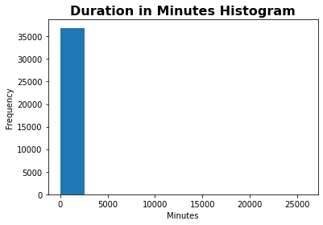

```python
# creating histogram using matplotlib for minutes column
plt.hist(df_bikes.duration_minutes);
plt.xlabel("Minutes")
plt.ylabel("Frequency")
plt.title("Duration in Minutes Histogram",fontsize = 16, fontweight = 'bold');
```

```python
df_bikes.duration_minutes.value_counts()
```

```
5.45      42
8.28      42
8.68      40
4.60      38
9.18      37
          ..
168.12     1
82.08      1
141.62     1
181.90     1
120.67     1
Name: duration_minutes, Length: 6375, dtype: int64
```

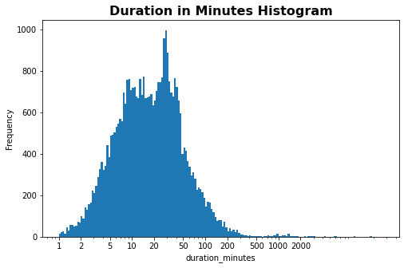

```python
#exploring data using log function as the data is not normalized
log_size = 0.025
bins = 10 ** np.arange(0, np.log10(df_bikes['duration_minutes'].max())+log_size, log_size)

plt.figure(figsize=[8, 5]);
plt.hist(data = df_bikes, x = 'duration_minutes', bins = bins);
plt.xscale('log');
plt.xticks([1, 2, 5, 10, 20, 50, 100, 200, 500, 1000, 2000], [1, 2, 5, 10, 20, 50, 100, 200, 500, 1000, 2000]);
plt.xlabel('duration_minutes')
plt.ylabel("Frequency")
plt.title("Duration in Minutes Histogram",fontsize = 16, fontweight = 'bold');
```

```python
df_bikes.duration_minutes.describe(percentiles =[0.99])
```

```
count    36917.000000
mean        38.278379
std        285.221479
min          1.020000
50%         17.450000
99%        218.690000
max      25906.620000
Name: duration_minutes, dtype: float64
```

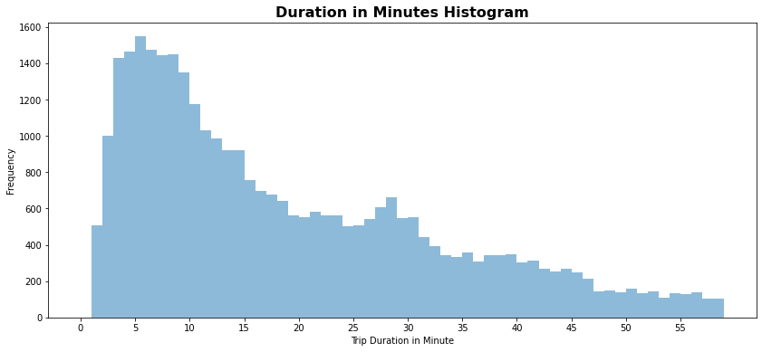

```python
# Creating histogram only for duration in minutes that fall in 99 % percentile that is 220 minutes by taking upper limit.
plt.figure(figsize=(14,6))
bins = np.arange(0, 60, 1)
ticks = np.arange(0, 60, 5)
plt.hist(data=df_bikes, x='duration_minutes', bins=bins, alpha = .5)
plt.xticks(ticks, ticks)
plt.xlabel('Trip Duration in Minute')
plt.ylabel("Frequency")
plt.title("Duration in Minutes Histogram",fontsize = 16, fontweight = 'bold');
```

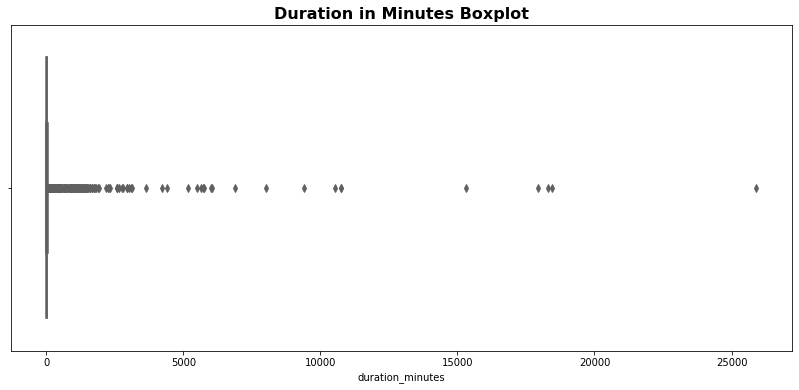

```python
# creating the box plot using seaborn boxplot function to dig deeper into minutes distribution
plt.figure(figsize=(14,6))
ax = sns.boxplot(data = df_bikes,x="duration_minutes",palette='Blues')
plt.title("Duration in Minutes Boxplot",fontsize = 16, fontweight = 'bold');
```

> As per the histogram and box plot, duration in minutes are right skewed and had outliers present in it.

## Quality - VI

### Assessing trip distance and calculating speed

```python
df_bikes.distance_miles.describe()
```

```
count    36917.000000
mean         0.609007
std          0.557685
min          0.000000
25%          0.136083
50%          0.530335
75%          0.903674
max         10.254784
Name: distance_miles, dtype: float64
```

```python
# creating speed column in dataframe for Speed in Miles per hour.
df_bikes['speed']= round(df_bikes.distance_miles/((df_bikes.duration_minutes)/60),2)
```

```python
# Checking speed column statistics
df_bikes.speed.describe()
```

```
count    36917.000000
mean         3.077197
std          2.731631
min          0.000000
25%          0.100000
50%          2.840000
75%          5.300000
max         13.270000
Name: speed, dtype: float64
```

#### As per the dataset instructions, if the speed is greater than 26 then those rows should be removed. But we don't have any value greater than 26 miles/hour

### Removing distance_miles == 0 but Duration is not 0.

```python
df = (df_bikes.query('distance_miles == 0'))
df
```

|  | tripduration | starttime | stoptime | start_station_id | start_station_name | start_station_latitude | start_station_longitude | end_station_id | end_station_name | end_station_latitude | ... | birth_year | gender | distance_miles | start_date | month | day | start_hourofday | user_age | duration_minutes | speed |
| --- | --- | --- | --- | --- | --- | --- | --- | --- | --- | --- | --- | --- | --- | --- | --- | --- | --- | --- | --- | --- | --- |
| 14 | 1703 | 2020-06-01 04:43:24.895 | 2020-06-01 05:11:48.857 | 3792 | Columbus Dr at Exchange Pl | 40.716870 | -74.032810 | 3792 | Columbus Dr at Exchange Pl | 40.716870 | ... | 1999 | Female | 0.0 | NaT | June | Monday | 4 | 21 | 28.38 | 0.0 |
| 15 | 1719 | 2020-06-01 04:43:27.347 | 2020-06-01 05:12:06.536 | 3792 | Columbus Dr at Exchange Pl | 40.716870 | -74.032810 | 3792 | Columbus Dr at Exchange Pl | 40.716870 | ... | 1969 | Unknown | 0.0 | NaT | June | Monday | 4 | 51 | 28.65 | 0.0 |
| 16 | 1707 | 2020-06-01 04:43:27.510 | 2020-06-01 05:11:54.907 | 3792 | Columbus Dr at Exchange Pl | 40.716870 | -74.032810 | 3792 | Columbus Dr at Exchange Pl | 40.716870 | ... | 1969 | Unknown | 0.0 | NaT | June | Monday | 4 | 51 | 28.45 | 0.0 |
| 17 | 30519 | 2020-06-01 04:43:32.561 | 2020-06-01 13:12:12.063 | 3792 | Columbus Dr at Exchange Pl | 40.716870 | -74.032810 | 3792 | Columbus Dr at Exchange Pl | 40.716870 | ... | 1969 | Unknown | 0.0 | NaT | June | Monday | 4 | 51 | 508.65 | 0.0 |
| 18 | 1726 | 2020-06-01 04:43:40.550 | 2020-06-01 05:12:26.936 | 3792 | Columbus Dr at Exchange Pl | 40.716870 | -74.032810 | 3792 | Columbus Dr at Exchange Pl | 40.716870 | ... | 2001 | Female | 0.0 | NaT | June | Monday | 4 | 19 | 28.77 | 0.0 |
| ... | ... | ... | ... | ... | ... | ... | ... | ... | ... | ... | ... | ... | ... | ... | ... | ... | ... | ... | ... | ... | ... |
| 36916 | 2828 | 2020-06-30 23:53:19.738 | 2020-07-01 00:40:28.576 | 3199 | Newport Pkwy | 40.728745 | -74.032108 | 3199 | Newport Pkwy | 40.728745 | ... | 1969 | Unknown | 0.0 | NaT | June | Tuesday | 23 | 51 | 47.13 | 0.0 |
| 36917 | 2729 | 2020-06-30 23:54:44.010 | 2020-07-01 00:40:13.647 | 3199 | Newport Pkwy | 40.728745 | -74.032108 | 3199 | Newport Pkwy | 40.728745 | ... | 1969 | Unknown | 0.0 | NaT | June | Tuesday | 23 | 51 | 45.48 | 0.0 |
| 36918 | 2788 | 2020-06-30 23:54:52.192 | 2020-07-01 00:41:20.650 | 3199 | Newport Pkwy | 40.728745 | -74.032108 | 3199 | Newport Pkwy | 40.728745 | ... | 1969 | Unknown | 0.0 | NaT | June | Tuesday | 23 | 51 | 46.47 | 0.0 |
| 36919 | 2702 | 2020-06-30 23:56:14.665 | 2020-07-01 00:41:16.782 | 3199 | Newport Pkwy | 40.728745 | -74.032108 | 3199 | Newport Pkwy | 40.728745 | ... | 1969 | Unknown | 0.0 | NaT | June | Tuesday | 23 | 51 | 45.03 | 0.0 |
| 36920 | 2649 | 2020-06-30 23:57:46.149 | 2020-07-01 00:41:55.506 | 3199 | Newport Pkwy | 40.728745 | -74.032108 | 3199 | Newport Pkwy | 40.728745 | ... | 1998 | Female | 0.0 | NaT | June | Tuesday | 23 | 22 | 44.15 | 0.0 |

8971 rows × 23 columns

```python
# query the df which has no 0 values in distance_miles column
df_clean = df_bikes.query('distance_miles != 0')
```

```python
# Checking data frame if distance_miles has 0 values
len(df_clean.query('distance_miles == 0'))
```

```
0
```

```python
df_clean.shape[0]
```

```
27946
```

### For further analysis copy the cleaned dataset to master dataset

```python
df_clean.to_csv('Newyork-2020-citibike-master-data.csv',index=False)
```

### Importing master data for further investigations

```python
df_master = pd.read_csv('Newyork-2020-citibike-master-data.csv')
df_master.head(5)
```

|  | tripduration | starttime | stoptime | start_station_id | start_station_name | start_station_latitude | start_station_longitude | end_station_id | end_station_name | end_station_latitude | ... | birth_year | gender | distance_miles | start_date | month | day | start_hourofday | user_age | duration_minutes | speed |
| --- | --- | --- | --- | --- | --- | --- | --- | --- | --- | --- | --- | --- | --- | --- | --- | --- | --- | --- | --- | --- | --- |
| 0 | 122 | 2020-06-01 00:02:21.750 | 2020-06-01 00:04:24.325 | 3792 | Columbus Dr at Exchange Pl | 40.716870 | -74.032810 | 3639 | Harborside | 40.719252 | ... | 1987 | Male | 0.180668 | NaN | June | Monday | 0 | 33 | 2.03 | 5.34 |
| 1 | 1282 | 2020-06-01 00:12:27.109 | 2020-06-01 00:33:50.054 | 3198 | Heights Elevator | 40.748716 | -74.040443 | 3276 | Marin Light Rail | 40.714584 | ... | 1988 | Male | 2.361559 | NaN | June | Monday | 0 | 32 | 21.37 | 6.63 |
| 2 | 186 | 2020-06-01 01:19:59.209 | 2020-06-01 01:23:05.893 | 3275 | Columbus Drive | 40.718355 | -74.038914 | 3681 | Grand St | 40.715178 | ... | 1987 | Male | 0.228816 | NaN | June | Monday | 1 | 33 | 3.10 | 4.43 |
| 3 | 131 | 2020-06-01 01:26:42.205 | 2020-06-01 01:28:53.804 | 3267 | Morris Canal | 40.712419 | -74.038526 | 3681 | Grand St | 40.715178 | ... | 1987 | Male | 0.195655 | NaN | June | Monday | 1 | 33 | 2.18 | 5.38 |
| 4 | 266 | 2020-06-01 01:27:33.709 | 2020-06-01 01:32:00.189 | 3639 | Harborside | 40.719252 | -74.034234 | 3186 | Grove St PATH | 40.719586 | ... | 1972 | Female | 0.465771 | NaN | June | Monday | 1 | 48 | 4.43 | 6.31 |

5 rows × 23 columns

```python
df_master.shape
```

```
(27946, 23)
```

```python
df_master.info()
```

```
<class 'pandas.core.frame.DataFrame'>
RangeIndex: 27946 entries, 0 to 27945
Data columns (total 23 columns):
 #   Column                   Non-Null Count  Dtype
---  ------                   --------------  -----
 0   tripduration             27946 non-null  int64
 1   starttime                27946 non-null  object
 2   stoptime                 27946 non-null  object
 3   start_station_id         27946 non-null  int64
 4   start_station_name       27946 non-null  object
 5   start_station_latitude   27946 non-null  float64
 6   start_station_longitude  27946 non-null  float64
 7   end_station_id           27946 non-null  int64
 8   end_station_name         27946 non-null  object
 9   end_station_latitude     27946 non-null  float64
 10  end_station_longitude    27946 non-null  float64
 11  bikeid                   27946 non-null  int64
 12  usertype                 27946 non-null  object
 13  birth_year               27946 non-null  int64
 14  gender                   27946 non-null  object
 15  distance_miles           27946 non-null  float64
 16  start_date               0 non-null      float64
 17  month                    27946 non-null  object
 18  day                      27946 non-null  object
 19  start_hourofday          27946 non-null  int64
 20  user_age                 27946 non-null  int64
 21  duration_minutes         27946 non-null  float64
 22  speed                    27946 non-null  float64
dtypes: float64(8), int64(7), object(8)
memory usage: 4.9+ MB
```

```python
# checking null values
df_master.isna().sum()
```

```
tripduration                   0
starttime                      0
stoptime                       0
start_station_id               0
start_station_name             0
start_station_latitude         0
start_station_longitude        0
end_station_id                 0
end_station_name               0
end_station_latitude           0
end_station_longitude          0
bikeid                         0
usertype                       0
birth_year                     0
gender                         0
distance_miles                 0
start_date                 27946
month                          0
day                            0
start_hourofday                0
user_age                       0
duration_minutes               0
speed                          0
dtype: int64
```

```python
# checking duplicated values
df_master.duplicated().sum()
```

```
0
```

## Univariant Analysis

### Exploring distribution of user age

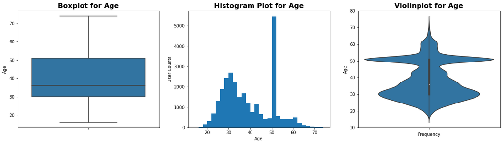

```python
# Exploring User Age Statistics using different charts such as boxplot, histogram, and violin plot
plt.figure(figsize = [20, 5])

plt.subplot(1,3,1)
sns.boxplot(data = df_master, y = 'user_age')
plt.ylabel("Age")
plt.title("Boxplot for Age",fontsize = 16, fontweight = 'bold');

plt.subplot(1, 3, 2)
bins = np.arange(df_master.user_age.min()-2, df_master.user_age.max()+2,2)
plt.hist(df_master.user_age, bins = bins)
plt.xlabel("Age")
plt.ylabel("User Counts")
plt.title("Histogram Plot for Age",fontsize = 16, fontweight = 'bold');

plt.subplot(1, 3, 3)
sns.violinplot(data = df_master, y = 'user_age')
plt.ylabel("Age")
plt.xlabel("Frequency")
plt.title("Violinplot for Age",fontsize = 16, fontweight = 'bold');
```

#### Based on the Histogram plot, frequency is high for age between 50-55

### Distribution of distance travelled

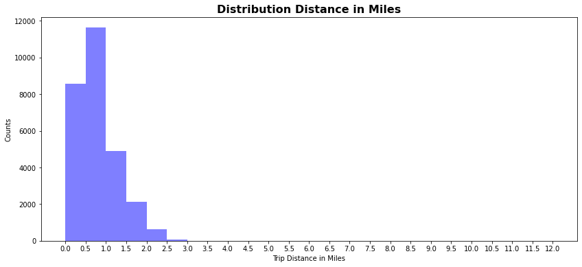

```python
# Exploring distribution of Distance covered by users using histogram chart. This is step perofmed as univariate analysis
plt.figure(figsize=(14,6))
bins = np.arange(0, df_master.distance_miles.max()+2, .5)
ticks = np.arange(0, df_master.distance_miles.max()+2, .5)
plt.hist(data=df_master, x='distance_miles', bins=bins, color='blue', alpha = .5)
plt.xticks(ticks);
plt.xlabel('Trip Distance in Miles')
plt.ylabel('Counts')
plt.title('Distribution Distance in Miles',fontsize = 16, fontweight = 'bold');
```

## Most of our users has travelled distance between 0.5 - 1 miles

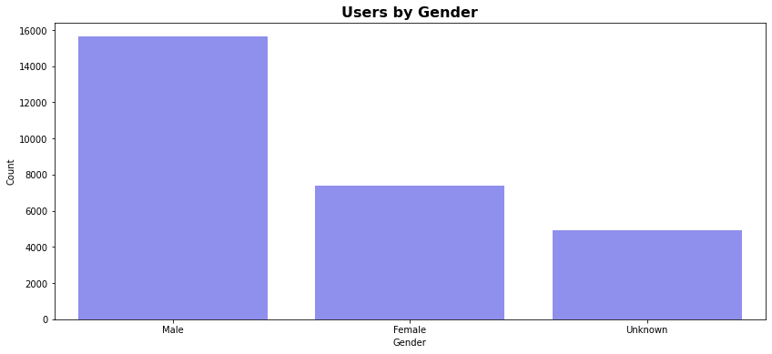

```python
# Creating chart to see how users are distributed by gender
plt.figure(figsize=(14,6))
gender_value = df_master.gender.value_counts().index
sns.countplot(data=df_master, x='gender', color="blue", alpha =.5, order =gender_value );
plt.xlabel('Gender');
plt.ylabel('Count')
plt.title('Users by Gender',fontsize = 16, fontweight = 'bold');
```

### Male user are more compare to other two types

```python
# using value_counts function of pandas to see usertype
df_master['usertype'].value_counts()
```

```
Subscriber    17053
Customer      10893
Name: usertype, dtype: int64
```

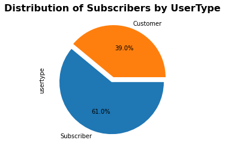

```python
ax=df_master.usertype.value_counts().plot.pie(explode = (0.05,0.05),autopct='%1.1f%%',counterclock = False)
plt.title('Distribution of Subscribers by UserType',fontsize = 16, fontweight = 'bold');
```

## Most of the user's in our data are the subscribers which is 61%.

## Exploring the dataset to check on which day highest number of users

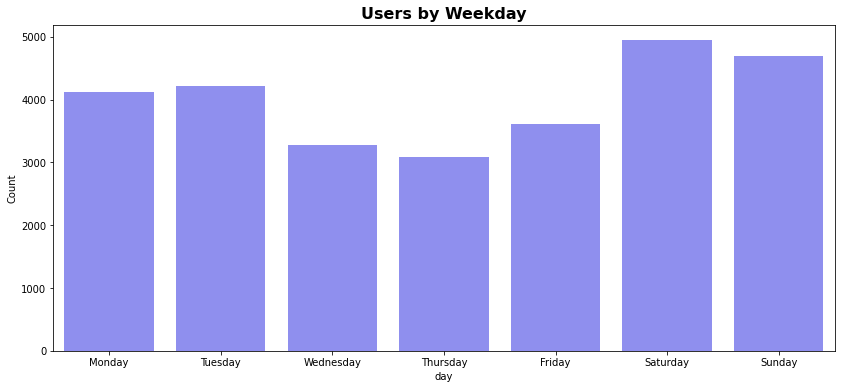

```python
# creating bar to see bike usage by days
plt.figure(figsize=(14,6))
day_value = df_master.groupby('day')['bikeid'].count().index
sns.countplot(data=df_master, x='day', color="blue", alpha =.5, hue_order = day_value );
plt.xlabel('day');
plt.ylabel('Count')
plt.title('Users by Weekday',fontsize = 16, fontweight = 'bold');
```

```python
df_master.groupby('day')['bikeid'].count().index
```

```
Index(['Friday', 'Monday', 'Saturday', 'Sunday', 'Thursday', 'Tuesday',
       'Wednesday'],
      dtype='object', name='day')
```

#### Mostly Saturday and Sundays the usage of cycles is more

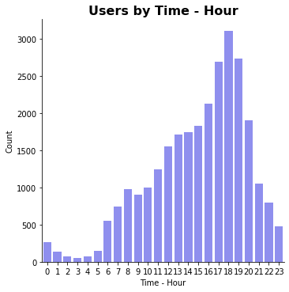

```python
# creating bar to see bike uage by hours of day
plt.figure(figsize=(20, 6))
sns.catplot(data = df_master, x='start_hourofday', kind='count', color="blue", alpha=.5)
plt.xlabel('Time - Hour');
plt.ylabel('Count')
plt.title('Users by Time - Hour',fontsize = 16, fontweight = 'bold');
```

### Usually in the Evening times i.e 4 - 8 pm the usage of bikes is more.

## Top Ten Stations

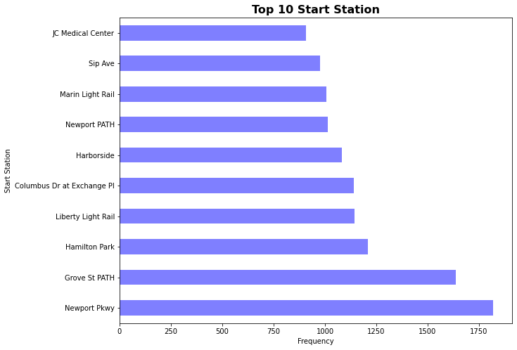

```python
# creating bar to see bike frequency by start station
plt.figure(figsize=(10, 8))
ax = df_master.start_station_name.value_counts().sort_values(ascending =False)[:10].plot(kind='barh',color="blue",alpha=.5)
plt.title('Top 10 Start Station',fontsize = 16, fontweight = 'bold')
ax.set_xlabel('Frequency')
ax.set_ylabel("Start Station");
```

[figure not shown]

```python
# creating bar to see bike frequency by end station
plt.figure(figsize=(10, 8))
ax = df_master.end_station_name.value_counts().sort_values(ascending =False)[:10].plot(kind='barh',color="blue",alpha=.5)
plt.title('Top 10 Start Station',fontsize = 16, fontweight = 'bold')
ax.set_xlabel('Frequency')
ax.set_ylabel("Start Station");
```

#### Newport pkwy and Grove St PATH are busiest station in terms of both start and end stations.

### Overall, based on Univariant analysis we have observe that:

> The frequency of users age is between 50-55.  
> Maximum users travelled distance of 0.5-1 miles/hour. Male Users are more compare to female users and unknown users. Most of the users in our data are subscribers which is 61%. On Weekends usage of service is more. During Evening time between 4 - 8 pm usage is more. Newport pkwy and Grove St PATH are busiest station in terms of both start and end stations.

## Trip duration VS User Type

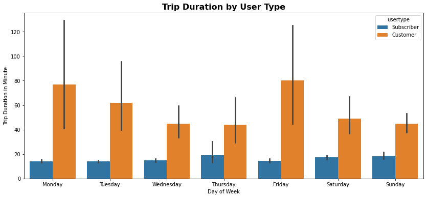

```python
plt.figure(figsize=(14,6))
sns.barplot(data=df_master, x='day', y='duration_minutes',hue='usertype');
plt.xlabel('Day of Week');
plt.ylabel('Trip Duration in Minute')
plt.title('Trip Duration by User Type',fontsize = 16, fontweight = 'bold');
```

### Customer user type has more trip duration compared to subsciber and it fluctuates in the week

## Distance vs users

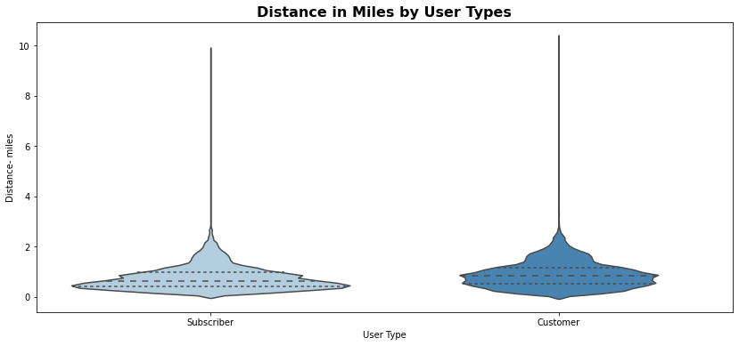

```python
# creating viloin chart to see distribution of distance by user type
plt.figure(figsize=(14,6))
sns.violinplot(data=df_master, x='usertype', y='distance_miles', palette='Blues',inner='quartile');
plt.xlabel('User Type');
plt.ylabel('Distance- miles')
plt.title('Distance in Miles by User Types',fontsize = 16, fontweight = 'bold');
```

#### Difference in user type is not significant in terms of distance covered and customer covered slightly more distances

## Distance Vs Gender

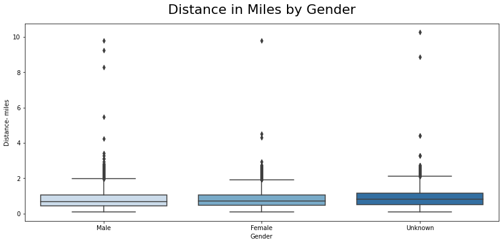

```python
# creating Boxplot chart to see distribution of distance by Gender
plt.figure(figsize=(14,6))
sns.boxplot(data=df_master, x='gender', y = 'distance_miles', palette='Blues')
plt.title("Distance in Miles by Gender", fontsize=22, y=1.03)
plt.xlabel("Gender")
plt.ylabel('Distance- miles')
```

#### There is no significant difference observed in gender in terms of distance covered.

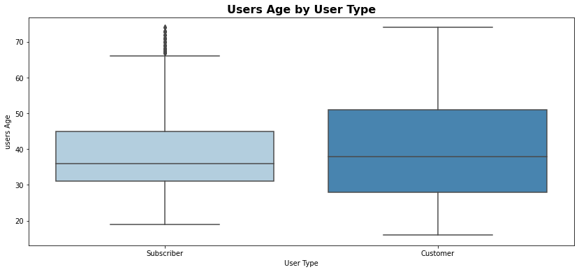

```python
# creating Boxplot chart to see distribution of dAge by user type
plt.figure(figsize=(14,6))
sns.boxplot(data=df_master, x='usertype', y='user_age', palette='Blues');
plt.xlabel('User Type');
plt.ylabel('users Age')
plt.title('Users Age by User Type',fontsize = 16, fontweight = 'bold');
```

#### Based on the observation subsribers more younger than customer. median age for subscribers is 35 while for customers is 38

### Based on BIvariant analysis, following conclusion are made:

> Customer user type has more trip duration than subscribers which further means that distance covered by customers is slightly more. Significant difference in terms of distance by gender is not found. Subscribers are younger than customers as per the mean age of both types.

## Multivariate Exploration

> Create plots of three or more variables to investigate your data even further. Make sure that your investigations are justified, and follow from your work in the previous sections.

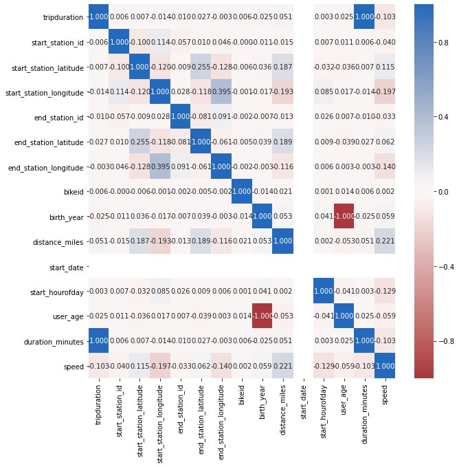

```python
# creating Corelation chart to see correlation between diffrent features in dataset
plt.figure(figsize = [10, 10])
sns.heatmap(df_master.corr(), annot = True, fmt = '.3f', cmap = 'vlag_r', center = 0);
```

```python
# creating list of measures which I am going to use in pair grid analysis
numeric_vars = ['duration_minutes', 'user_age', 'distance_miles']
```

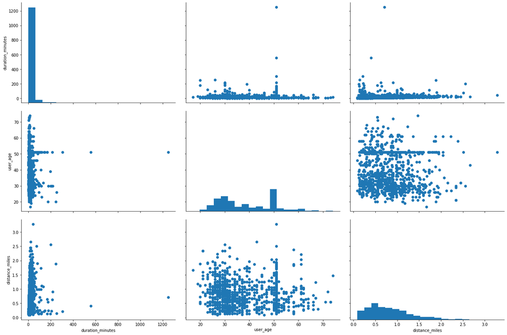

```python
# creating pair grid charts, and using 1000 sample of data to make analysis faster
g = sns.PairGrid(data = df_master.sample(1000), vars = numeric_vars, height = 4, aspect = 1.5)
g = g.map_diag(plt.hist, bins = 20);
g.map_offdiag(plt.scatter);
```

### There is no strong correlation in any factors.

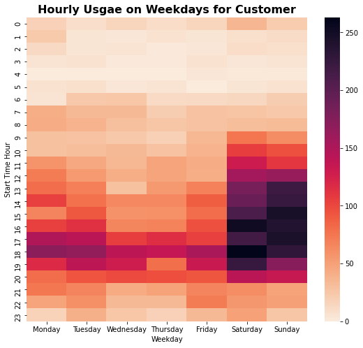

```python
# creating heatmap for customers  for hourly usage of bike on weekdays as a multivarite chart
plt.figure(figsize=(14,10))
df_master['day'] = pd.Categorical(df_master['day'],
                                                categories=['Monday', 'Tuesday', 'Wednesday', 'Thursday', 'Friday', 'Saturday', 'Sunday'],
                                                ordered=True)
plt.figure(figsize=(9,8))

df_customer = df_master.query('usertype == "Customer"').groupby(["start_hourofday", "day"])["bikeid"].size().reset_index()
df_customer = df_customer.pivot("start_hourofday", "day", "bikeid")
sns.heatmap(df_customer, cmap="rocket_r")

plt.title("Hourly Usgae on Weekdays for Customer", fontsize = 16, fontweight = 'bold');
plt.xlabel('Weekday')
plt.ylabel('Start Time Hour')
```

### In Customer types, On weekend evenings more users are using the service

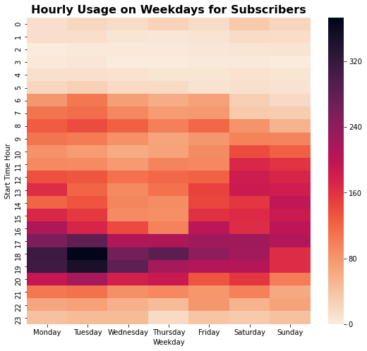

```python
# creating heatmap for subscribers  for hourly usage of bike on weekdays as a multivarite chart
plt.figure(figsize=(14,10))
df_master['day'] = pd.Categorical(df_master['day'],
                                                categories=['Monday', 'Tuesday', 'Wednesday', 'Thursday', 'Friday', 'Saturday', 'Sunday'],
                                                ordered=True)
plt.figure(figsize=(9,8))

df_customer = df_master.query('usertype == "Subscriber"').groupby(["start_hourofday", "day"])["bikeid"].size().reset_index()
df_customer = df_customer.pivot("start_hourofday", "day", "bikeid")
sns.heatmap(df_customer, cmap="rocket_r")

plt.title("Hourly Usage on Weekdays for Subscribers", fontsize = 16, fontweight = 'bold');
plt.xlabel('Weekday')
plt.ylabel('Start Time Hour');
```

### Based on multivariant analysis, observations found are:

#### None of factores has strong correleation. most of the customers use the service on weekends and for subscribers it is moreon weekdays